# Lake Water Quality Analysis

Derek Fedak

Thursday 24 February, 2022

# LAGOS Analysis

## Loading in data

### First download and then specifically grab the locus (or site lat longs)

```r
#Lagos download script
#lagosne_get(dest_folder = LAGOSNE:::lagos_path(),overwrite=T)

#Load in lagos
lagos <- lagosne_load()
#Grab the lake centroid info
lake_centers <- lagos$locus

# Make an sf object
spatial_lakes <- st_as_sf(lake_centers,coords=c('nhd_long','nhd_lat'),
                          crs=4326)

#Grab the water quality data
nutr <- lagos$epi_nutr

#Look at column names
#names(nutr)
```

### Subset columns nutr to only keep key info that we want

```r
clarity_only <- nutr %>%
  select(lagoslakeid,sampledate,chla,doc,secchi) %>%
  mutate(sampledate = as.character(sampledate) %>% ymd(.))
```

### Keep sites with at least 200 observations

```r
#Look at the number of rows of dataset
#nrow(clarity_only)

chla_secchi <- clarity_only %>%
  filter(!is.na(chla),
         !is.na(secchi))

# How many observatiosn did we lose?
# nrow(clarity_only) - nrow(chla_secchi)


# Keep only the lakes with at least 200 observations of secchi and chla
chla_secchi_200 <- chla_secchi %>%
  group_by(lagoslakeid) %>%
  mutate(count = n()) %>%
  filter(count > 200)
```

### Join water quality data to spatial data

```r
spatial_200 <- inner_join(spatial_lakes,chla_secchi_200 %>%
                            distinct(lagoslakeid,.keep_all=T),
                          by='lagoslakeid')
```

### Mean Chl_a map

```r
### Take the mean chl_a and secchi by lake

mean_values_200 <- chla_secchi_200 %>%
  # Take summary by lake id
  group_by(lagoslakeid) %>%
  # take mean chl_a per lake id
  summarize(mean_chl = mean(chla,na.rm=T),
            mean_secchi=mean(secchi,na.rm=T)) %>%
  #Get rid of NAs
  filter(!is.na(mean_chl),
         !is.na(mean_secchi)) %>%
  # Take the log base 10 of the mean_chl
  mutate(log10_mean_chl = log10(mean_chl))

#Join datasets
mean_spatial <- inner_join(spatial_lakes,mean_values_200,
                          by='lagoslakeid')

#Make a map
mapview(mean_spatial,zcol='log10_mean_chl')
```

[interactive chart not shown]

# Class work

## 1) What is the correlation between Secchi Disk Depth and Chlorophyll a for sites with at least 200 observations?

- Here, I just want a plot of chla vs secchi for all sites

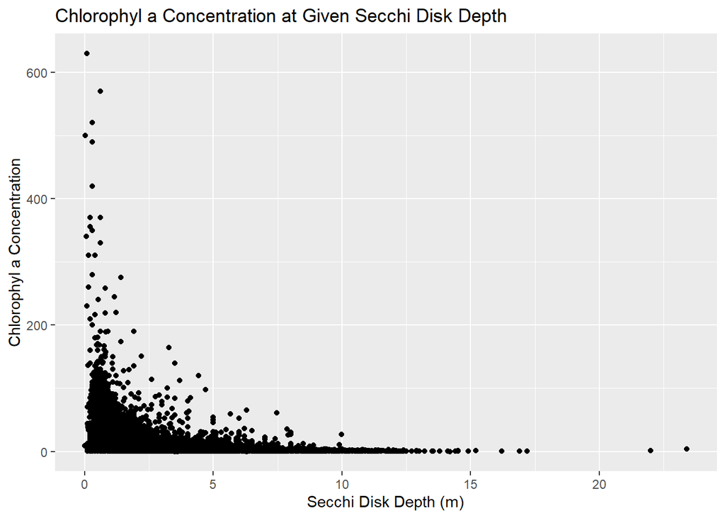

```r
ggplot(chla_secchi_200, aes(x=secchi, y=chla)) +
  xlab("Secchi Disk Depth (m)") +
  ylab("Chlorophyl a Concentration") +
  ggtitle("Chlorophyl a Concentration at Given Secchi Disk Depth") +
  geom_point()
```

## Why might this be the case?

### Answer

We see a pretty strong negative correlation between secchi disk depth and cholorophyl a concentration. While some surface or close-to-surface secchi disk readings show low chlorophyll a concentrations, we will see cholorophyll a concentrations decrease with increasing water depth as light is less able to permeate to deeper depths. Since chlorophyll a is a photosynthetic compound present in aquatic algae and plants, concentration decreases with less light and nutrients.

## 2) What states have the most data?

### 2a) First you will need to make a lagos spatial dataset that has the total number of counts per site.

```r
site_count <- chla_secchi %>%
  group_by(lagoslakeid) %>%
  mutate(count = n()) %>%
  distinct(lagoslakeid, .keep_all=T)


spatial_site_count <- inner_join(spatial_lakes,site_count %>%
                                   distinct(lagoslakeid,.keep_all=T),
                                 by='lagoslakeid')
```

```r
state_sites <- st_join(spatial_site_count, us_states())
```

### 2c) Then you will want to group by state and sum all the observations in that state and arrange that data from most to least total observations per state.

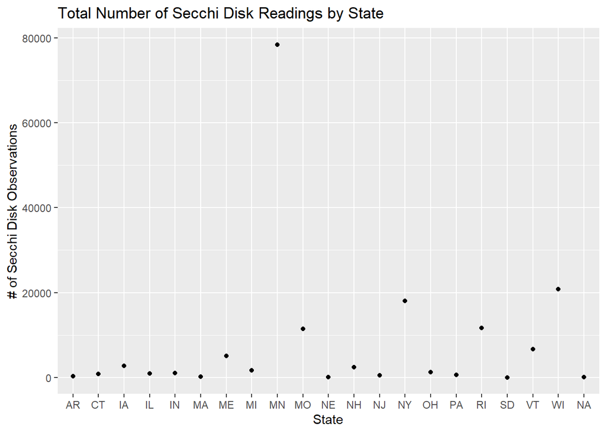

```r
state_site_count <- state_sites %>%
  group_by(name) %>%
  mutate(observations = sum(count)) %>%
  distinct(name, .keep_all=T)

#state_site_count[order(state_site_count$observations),]

ggplot(state_site_count, aes(x=state_abbr, y=observations)) +
  geom_point() +
  xlab("State") +
  ylab("# of Secchi Disk Observations") +
  ggtitle("Total Number of Secchi Disk Readings by State")
```

### Answer 2)

Minnesota has the most observations, and it isn’t close. Maine, Missouri, New York, Rhode Island, Vermont, and Wisconsin are a distant second group. Due to their area, Rhode Island and Vermont have a higher density of observations per area.

## 3 Is there a spatial pattern in Secchi disk depth for lakes with at least 200 observations?

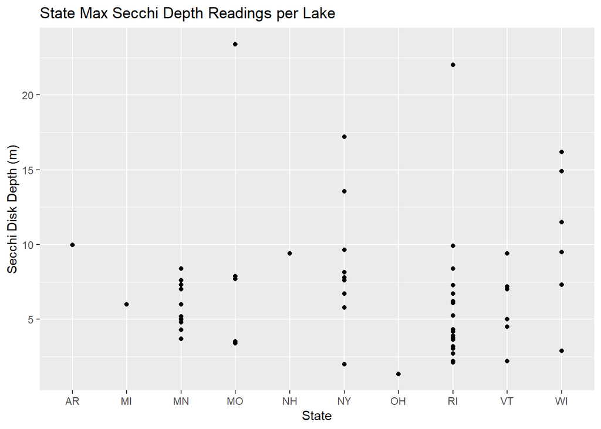

```r
#Combine lakes with >200 observations to spatial data
secchi_200_lagos <- inner_join(spatial_lakes,chla_secchi_200, by='lagoslakeid')

#Combine that output to states spatial data, retain count and keep only max secchi depth
secchi_200_max_states <- st_join(secchi_200_lagos, us_states()) %>%
  group_by(lagoslakeid) %>%
  slice_max(secchi)

ggplot(secchi_200_max_states, aes(x=state_abbr, y=secchi)) +
  geom_point() +
  xlab("State") +
  ylab("Secchi Disk Depth (m)") +
  ggtitle("State Max Secchi Depth Readings per Lake")
```

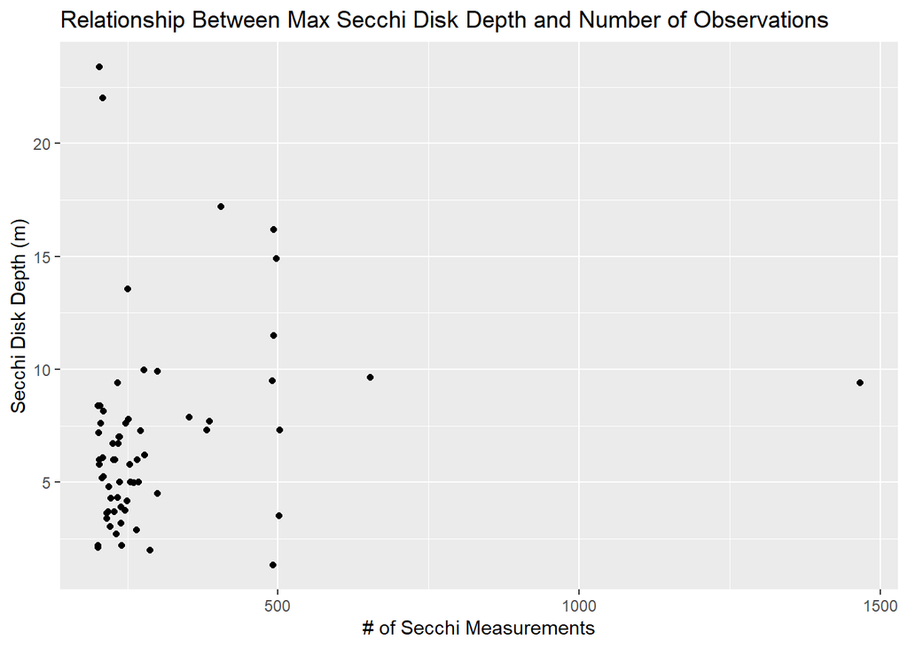

```r
ggplot(secchi_200_max_states, aes(x=count, y=secchi)) +
  geom_point() +
  xlab("# of Secchi Measurements") +
  ylab("Secchi Disk Depth (m)") +
  ggtitle("Relationship Between Max Secchi Disk Depth and Number of Observations")
```

```r
mapview(secchi_200_max_states, zcol = 'secchi', canvas=T)
```

[interactive chart not shown]

### Answer 3)

There does not appear to be a discernible pattern in max Secchi disk depth once >200 measurements are taken. Our greatest depth values (two readings >20m) occurred in lakes in Missouri and Rhode Island with 203 and 209 observations, respectively. All other max Secchi disk depths for lakes in these states were <10m. New York and Wisconsin had the greatest spread of disk depth measurements without much consistency. Minnesota, Rhode Island, and Vermont had the greatest clustering of max Secchi disk depth, excluding Rhode Island’s deepest lake reading at 22m. An inspection of our map shows that lakes are largely clustered around St. Paul-Minneapolis in MN as well as within RI due to its smaller area. The remaining states have a greater spatial distribution of readings across the state.